# Seurat workflow of the integrated day 10 data

Fabio Sacher

05.09.2025

Render this script with > sbatch ~/spinal_cord_paper/scripts/Seurat_Gg_day_10_int_render.sh

# load the data

the following workflow is based on: - [https://github.com/satijalab/seurat/issues/1500] Cell cycle regression - [https://github.com/satijalab/seurat/issues/1836] General workflow - [https://github.com/satijalab/seurat/issues/2590] Integrate all features (although used in the integration script)

```r
library(Seurat)
```

```r
library(dplyr)
library(Rtsne)
library(RColorBrewer)
library(tidyr)
library(ggplot2)
library(gridExtra)
```

```r
library(patchwork)
library(cowplot)
```

```r
library(ggdendro)
```

```r
gnames <- modplots::gnames
# load the integrated seurat
my.int <- readRDS(file = "~/spinal_cord_paper/data/Gg_day10_integrated_050925.rds")

my.int@project.name <- "Gg_day10_int"

my.int
```

Date: 09.09.25

# inspect

We order the plot by nCount_RNA to prevent overplotting of the last sample (default order is the group.by ident).

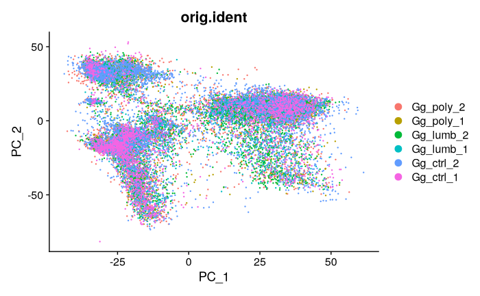

[figure not shown]

```r
# have a look at the PC and the previously calculated UMAP
PCAPlot(
  my.int,
  group.by = "orig.ident",
  order = "nCount_RNA"
  )
```

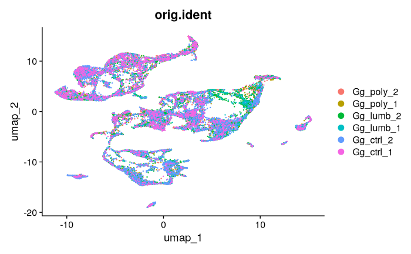

```r
DimPlot(
  my.int,
  reduction = "umap",
  group.by = "orig.ident",
  order = "nCount_RNA"
  )
```

# cell cycle scoring

Now we can score the cell cycle stage, using Seurats function. For this wee need the ortholog of the distributed cell stage marker lists.

We do the CC.difference calculation at this stage - and not prior to integration - based on the suggestion from: [https://github.com/satijalab/seurat/issues/1500]

```r
# Load the orhtology table
ortho_gg_mm_v102 <- readRDS("~/spinal_cord_paper/data/ortho_gg_mm_v102.rds")

colnames(ortho_gg_mm_v102) <- c(
  "GG_gene_ID",
  "GG_gene_Name",
  "MM_gene_ID",
  "MM_gene_Name",
  "ortho_conf",
  "homolog_type"
)

# A list of cell cycle markers, from Tirosh et al, 2015, is loaded with Seurat.  We can
# segregate this list into markers of G2/M phase and markers of S phase
s.genes <- ortho_gg_mm_v102 %>%
  dplyr::mutate(MM_gene_Name = toupper(MM_gene_Name)) %>%
  dplyr::filter(MM_gene_Name %in% cc.genes$s.genes) %>%
  dplyr::arrange(match(MM_gene_Name, cc.genes$s.genes)) %>%
  dplyr::pull(GG_gene_ID)

g2m.genes <- ortho_gg_mm_v102 %>%
  dplyr::mutate(MM_gene_Name = toupper(MM_gene_Name)) %>%
  dplyr::filter(MM_gene_Name %in% cc.genes$g2m.genes) %>%
  dplyr::arrange(match(MM_gene_Name, cc.genes$g2m.genes)) %>%
  dplyr::pull(GG_gene_ID)

t0 <- Sys.time()
my.int <- CellCycleScoring(
  my.int,
  s.features = s.genes,
  g2m.features = g2m.genes,
  set.ident = TRUE
  )
paste0("Seurats CC scoring took ", Sys.time() - t0, " seconds to run.")
```

```
[1] "Seurats CC scoring took 2.27016568183899 seconds to run."
```

```r
my.int$CC.Difference.seurat <- my.int$S.Score - my.int$G2M.Score
# view cell cycle scores and phase assignments
head(my.int[[]])
```

|  | orig.ident | nCount_RNA | nFeature_RNA | percent.mt | percent.rb | nCount_SCT | nFeature_SCT | S.Score | G2M.Score | Phase | old.ident | CC.Difference.seurat | SCT_snn_res.1.2 | seurat_clusters |
| --- | --- | --- | --- | --- | --- | --- | --- | --- | --- | --- | --- | --- | --- | --- |
| AAACCCAAGCTGTTAC-1_1 | Gg_ctrl_1 | 7011 | 2714 | 5.434318 | 17.68649 | 12857 | 2907 | -0.3943987 | -0.3336553 | G1 | 19 | -0.06074334 | 18 | 19 |
| AAACCCACATTGACCA-1_1 | Gg_ctrl_1 | 25548 | 5269 | 3.945514 | 18.73336 | 14170 | 4518 | -0.4859003 | 6.3481504 | G2M | 1 | -6.83405078 | 0 | 1 |
| AAACCCAGTGAGTGAC-1_1 | Gg_ctrl_1 | 15767 | 4268 | 4.300121 | 22.50904 | 14242 | 4267 | 2.1052414 | 1.1897946 | S | 1 | 0.91544686 | 0 | 1 |
| AAACGAAAGCCTCGTG-1_1 | Gg_ctrl_1 | 12876 | 3745 | 5.180180 | 22.64678 | 13176 | 3745 | 1.6846749 | -0.4510882 | S | 1 | 2.13576307 | 0 | 1 |
| AAACGAAAGTATGGCG-1_1 | Gg_ctrl_1 | 18910 | 4396 | 4.579588 | 21.27446 | 14223 | 4362 | -0.2462078 | 7.1609955 | G2M | 1 | -7.40720332 | 0 | 1 |
| AAACGAACACTCGATA-1_1 | Gg_ctrl_1 | 7940 | 3174 | 6.662469 | 16.00756 | 12741 | 3248 | -0.6986356 | -1.0079395 | G1 | 13 | 0.30930387 | 12 | 13 |

```r
rm(t0, s.genes, g2m.genes)
```

# rescale integrated assay

We rescale the data to regress out the CC.difference

```r
all_genes <- rownames(my.int)

my.int <- ScaleData(
  my.int,
  features = all_genes,
  vars.to.regress = "CC.Difference.seurat"
)
```

# PCA

[figure not shown]

# Dim Reduction

We will run the tSNE. Using the FFT-accelerated Interpolation-based t-SNE (FIt-SNE). We run two, a normal tSNE, and an exaggerated tSNE, where clusters are tighter togheter. This is located under the xtsne name.

# Clustering

[figure not shown]

```r
# tree based on PCA dims
my.int <- BuildClusterTree(my.int, dims = my.dimensions, verbose = F)
plot(Tool(object = my.int, slot = 'BuildClusterTree'))
```

[output not shown]

Now that we have the final reductions, we’ll choose one and we look at the statistics of the cells.

```r
cand_genes <-  c("OLIG2", "SOX9", "TUBB3", "SHH", "SLC18A3", "GATA2", "PAX2",
                 "TLX3", "IGFBP7", "HBBA", "IFI30", "MSX2", "PLP1", "CDH5",
                 "ENO1", "GSTA4", "GBE1", "RSPO1", "LECT1")

plots <- list()

for (i in seq(cand_genes)) {
  plots[[i]] <- modplots::mFeaturePlot(my.int, my.features = c(cand_genes[i],cand_genes[i]), gnames = gnames)
}
```

# tSNE plots broad cluster

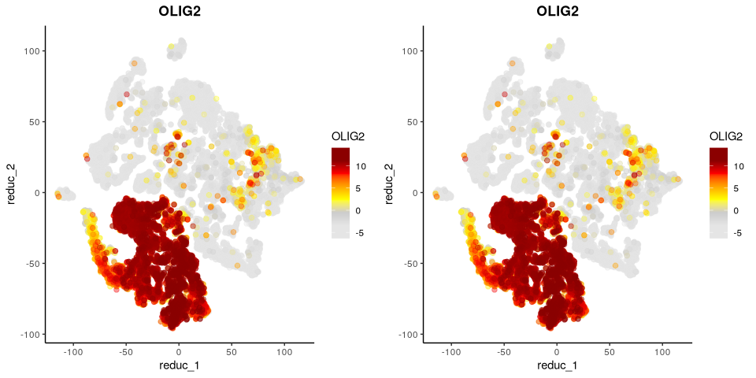

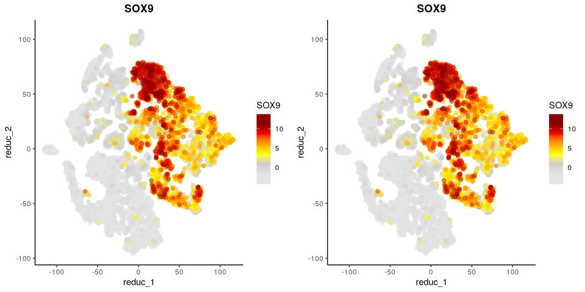

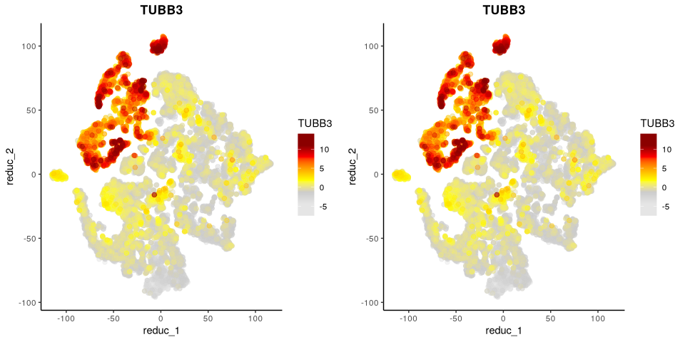

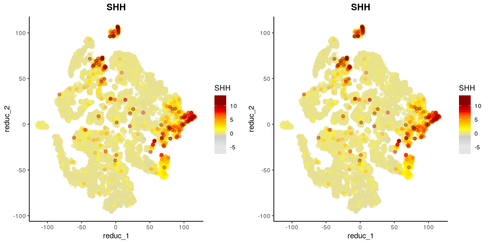

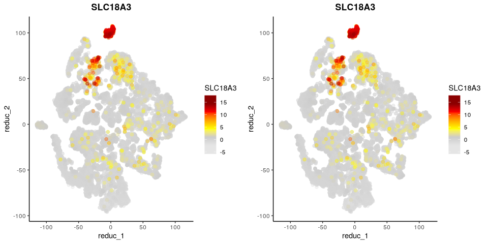

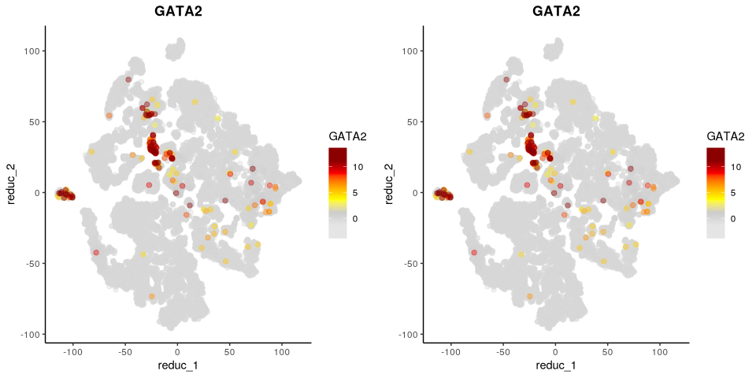

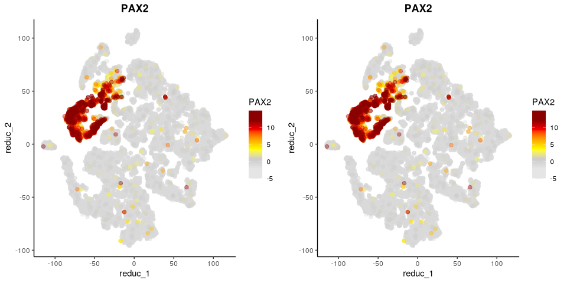

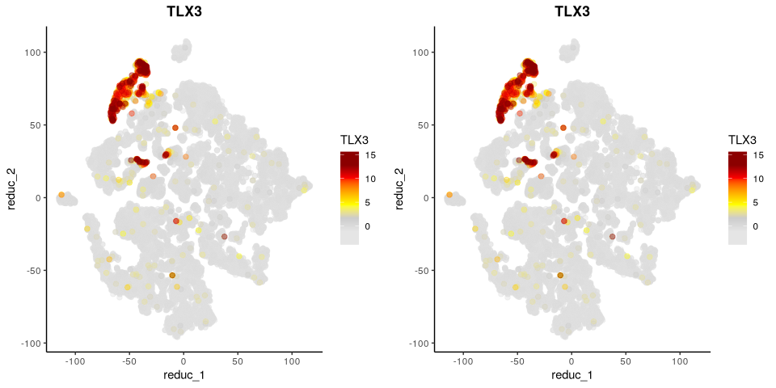

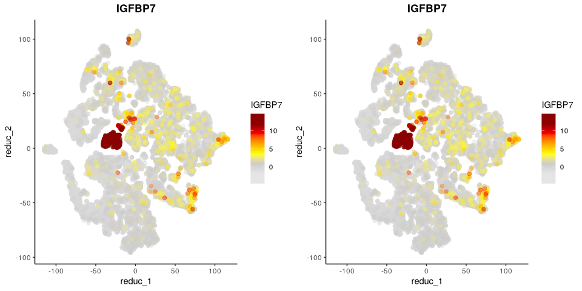

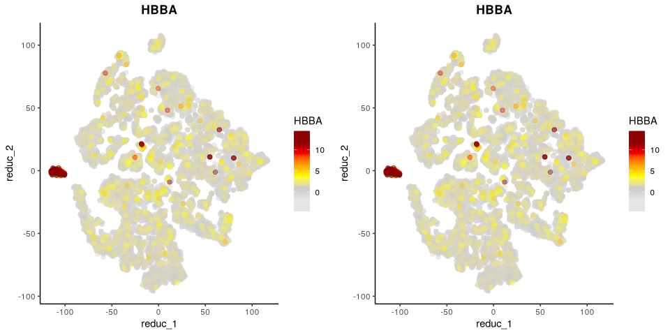

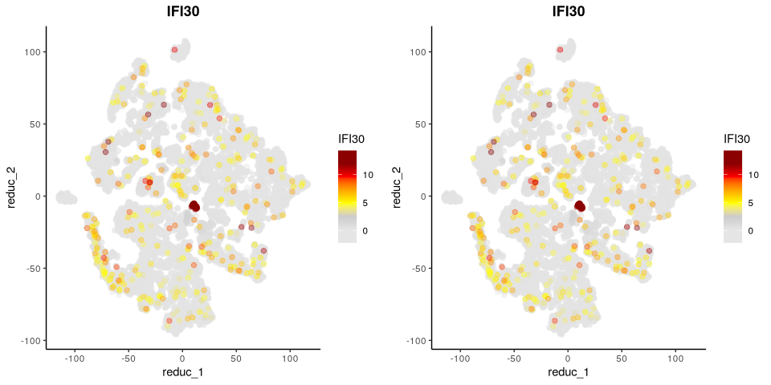

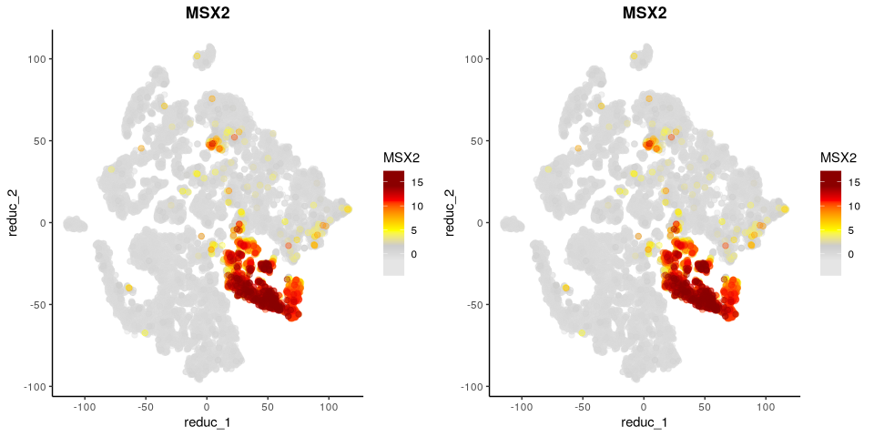

[7 more figures not shown]

```r
cand_genes <-  c("OLIG2", "SOX9", "TUBB3", "SHH", "SLC18A3", "GATA2", "PAX2",
                 "TLX3", "IGFBP7", "HBBA", "IFI30", "MSX2", "PLP1", "CDH5",
                 "ENO1", "GSTA4", "GBE1", "RSPO1", "LECT1")

plots <- list()

for (i in seq(cand_genes)) {
  plots[[i]] <- modplots::mFeaturePlot(my.int, my.features = c(cand_genes[i],cand_genes[i]), gnames = gnames)
}
```

```r
# set and get dim.reduct embeddings
my.reduc <- "tsne"
emb <- data.frame(Embeddings(my.int, my.reduc))
colnames(emb) <- c("reduc_1", "reduc_2")

meta <- my.int[[]] %>%
  tibble::rownames_to_column("cell_ID")


my.plots = list()

my.plots[[1]] = ggplot(emb[meta[order(meta$nCount_RNA),]$cell_ID, ], aes(x = reduc_1, y = reduc_2)) +
    geom_point(aes(color=sort(meta$nCount_RNA)), size=1, alpha = 0.4, pch = 19) +
    scale_colour_gradientn(colours = c("gray90","gray90","gray80","yellow", "orange", "red", "darkred", "darkred")) +
    theme_classic() + labs(colour="UMI count", x = paste0(my.reduc, "_1"), y = paste0(my.reduc, "_2"))

my.plots[[2]] = ggplot(emb[meta[order(meta$nFeature_RNA),]$cell_ID, ], aes(x = reduc_1, y = reduc_2)) +
    geom_point(aes(color=sort(meta$nFeature_RNA)), size=1, alpha = 0.4, pch = 19) +
    scale_colour_gradientn(colours = c("gray90","gray90","gray80","yellow", "orange", "red", "darkred", "darkred")) +
    theme_classic() + labs(colour="gene count", x = paste0(my.reduc, "_1"), y = paste0(my.reduc, "_2"))

my.plots[[3]] = ggplot(emb[meta[order(meta$nCount_SCT),]$cell_ID, ], aes(x = reduc_1, y = reduc_2)) +
    geom_point(aes(color=sort(meta$nCount_RNA)), size=1, alpha = 0.4, pch = 19) +
    scale_colour_gradientn(colours = c("gray90","gray90","gray80","yellow", "orange", "red", "darkred", "darkred")) +
    theme_classic() + labs(colour="UMI count (SCT)", x = paste0(my.reduc, "_1"), y = paste0(my.reduc, "_2"))

my.plots[[4]] = ggplot(emb[meta[order(meta$nFeature_SCT),]$cell_ID, ], aes(x = reduc_1, y = reduc_2)) +
    geom_point(aes(color=sort(meta$nFeature_RNA)), size=1, alpha = 0.4, pch = 19) +
    scale_colour_gradientn(colours = c("gray90","gray90","gray80","yellow", "orange", "red", "darkred", "darkred")) +
    theme_classic() + labs(colour="gene count (SCT)", x = paste0(my.reduc, "_1"), y = paste0(my.reduc, "_2"))

my.plots[[5]] = ggplot(emb[meta[order(meta$percent.mt),]$cell_ID, ], aes(x = reduc_1, y = reduc_2)) +
    geom_point(aes(color=(sort(meta$percent.mt))), size=1, alpha = 0.4, pch = 19) +
    scale_colour_gradientn(colours = c("gray90","gray80","yellow", "orange", "red", "darkred", "darkred")) +
    theme_classic() + labs(colour="log1p MT percent", x = paste0(my.reduc, "_1"), y = paste0(my.reduc, "_2"))

my.plots[[6]] = ggplot(emb[meta[order(meta$CC.Difference.seurat),]$cell_ID, ], aes(x = reduc_1, y = reduc_2)) +
    geom_point(aes(color=sort(meta$CC.Difference.seurat)), size=1, alpha = 0.4, pch = 19) +
    scale_colour_gradientn(colours = c("gray90","gray90","gray80","yellow", "orange", "red", "darkred", "darkred")) +
    theme_classic() + labs(colour="Cell Cycle\nS-G2M", x = paste0(my.reduc, "_1"), y = paste0(my.reduc, "_2"))

my.plots[[7]] = ggplot(emb[meta[order(meta$percent.rb),]$cell_ID, ], aes(x = reduc_1, y = reduc_2)) +
    geom_point(aes(color=sort(meta$percent.rb)), size=2, alpha = 0.4, pch = 19) +
    scale_colour_gradientn(colours = c("gray90","gray90","gray80","yellow", "orange", "red", "darkred", "darkred")) +
    theme_classic() + labs(colour="percent.rb")

grid.arrange(grobs=my.plots, ncol=2)
```

[output not shown]

[output not shown]

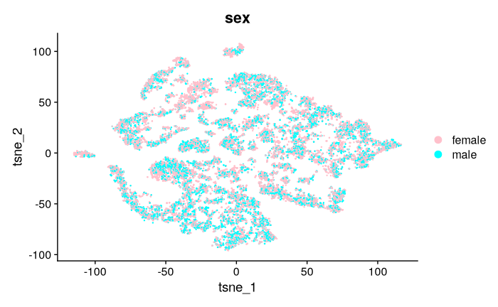

```r
female <- c("Gg_ctrl_2", "Gg_lumb_2", "Gg_poly_2")

my.int[[]] <- my.int[[]] %>%
  mutate(sex = case_when(
    orig.ident %in% female ~ "female",
    TRUE ~ "male"
  ))

sex_tsne <- TSNEPlot(my.int, group.by = "sex", shuffle = TRUE, cols = c("pink","cyan"))
sex_tsne
```

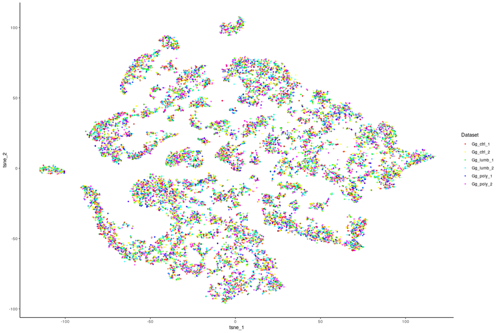

```r
dim.orig.ident <- ggplot(emb, aes(x = reduc_1, y = reduc_2)) +
    geom_point(aes(color=meta$orig.ident[sample(x = seq(nrow(emb)), size = nrow(emb), replace = FALSE)]), size=0.8, alpha = 0.6, pch = 19) +
    scale_colour_manual(values = rainbow(length(table(my.int@meta.data$orig.ident))) ) +
    theme_classic() + labs(colour="Dataset", x = paste0(my.reduc, "_1"), y = paste0(my.reduc, "_2"))

dim.orig.ident
```

# DE analysis

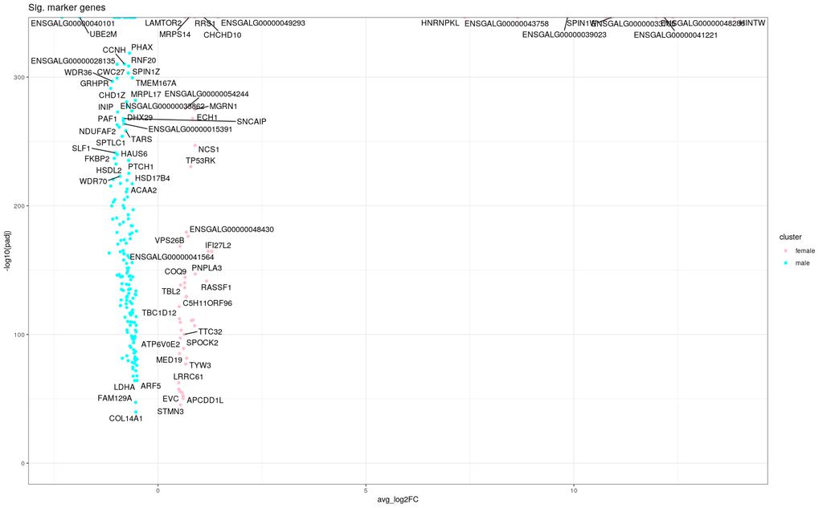

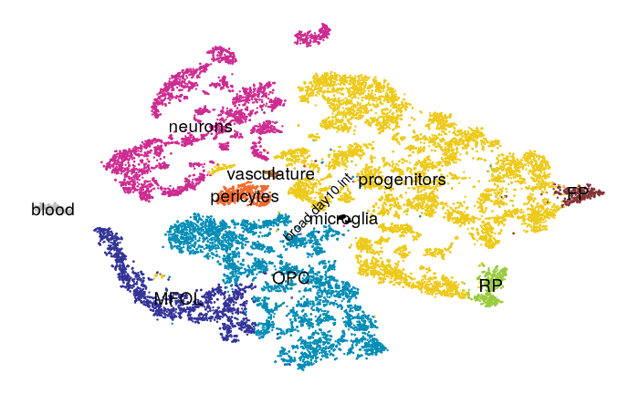

# save

```r
saveRDS(my.int, paste0("~/spinal_cord_paper/data/", my.int@project.name, "_seurat_",format(Sys.Date(), "%d%m%y"),".rds"))
1+1
```

```
[1] 2
```

```r
write.table(semarkers, sep = "\t", row.names = T, col.names = T,
            file = paste0("~/spinal_cord_paper/data/", my.int@project.name, "_fullDE_female_vs_male_",format(Sys.Date(), "%d%m%y"),".txt"), quote = F)

pdf("~/spinal_cord_paper/figures/Gg_day10_int_broad_cluster_tsne.pdf", width = 10, height = 10)
broad_tsne
sex_tsne + ggtitle("Day10int sex (pink female/cyan male") + theme_void() + NoLegend()
```

```r
dev.off()
```

```r
pdf("~/spinal_cord_paper/figures/Gg_da10_int_sex_volplot.pdf")
volplot
```

```r
no_W_volplot
dev.off()
```

```r
# Date and time of Rendering
Sys.time()

sessionInfo()
```